# Summary of independent t-test for `dimensao8.fss`,`dimensao7.fss`,`dimensao5.fss`,`dimensao2.fss` with `cenário`

##### Applying normality in dimensao2.fss to reduce skewness

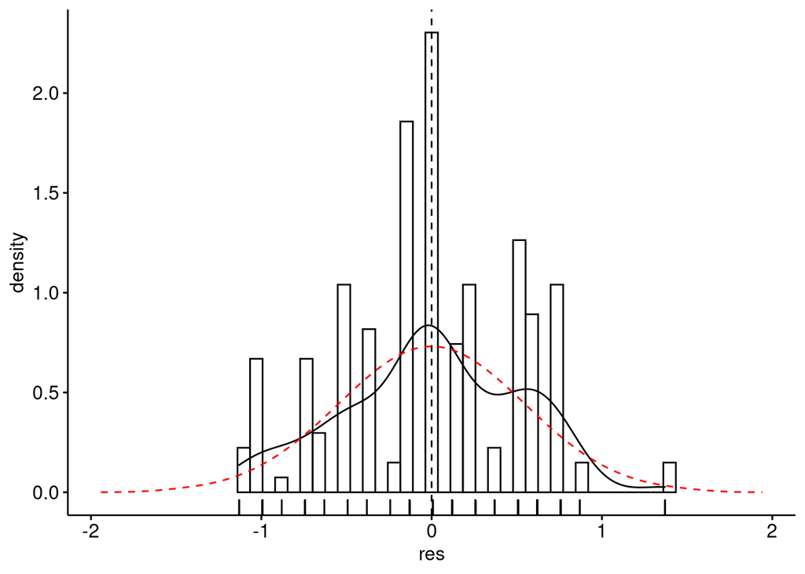

```r
density_res_plot(rdat,"dimensao2.fss",iv,dv.var="var")
```

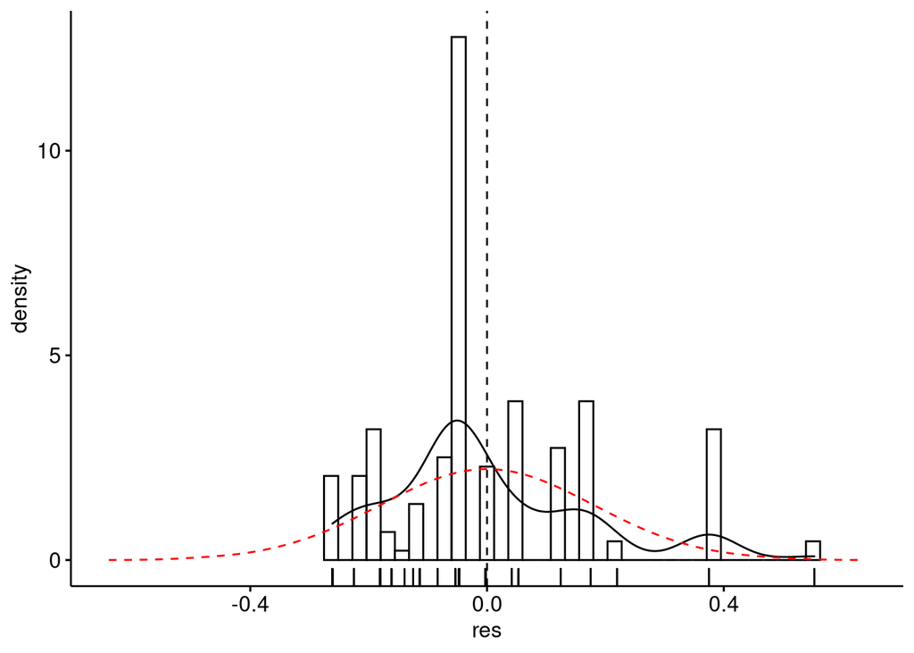

```r
rdat[["dimensao2.fss"]] <- 1/(max(rdat[["dimensao2.fss"]]+1) - rdat[["dimensao2.fss"]])
density_res_plot(rdat,"dimensao2.fss",iv,dv.var="var")
```

#### Removing data that affect normality (extreme values)

```r
non.normal <- list(

)
sdat <- remove_from_datatable(rdat, non.normal, wid, "var")
```

#### Checking normality assumption in the groups

```r
normality_test_per_group(sdat, dvs, iv, dv.var = 'var')
```

| var | variable | cenário | n | skewness | kurtosis | symmetry | statistic | method | p | p.signif | normality |
| --- | --- | --- | --- | --- | --- | --- | --- | --- | --- | --- | --- |
| dimensao8.fss | dimensao8.fss | gamificado | 110 | -0.317 | -0.123 | YES | 2.062 | D’Agostino | 0.357 | ns | QQ |
| dimensao8.fss | dimensao8.fss | não gamificado | 73 | -0.474 | 0.300 | YES | 4.138 | D’Agostino | 0.126 | ns | YES |
| dimensao7.fss | dimensao7.fss | gamificado | 110 | -0.250 | -1.232 | YES | 39.847 | D’Agostino | <0.001 | **** | QQ |
| dimensao7.fss | dimensao7.fss | não gamificado | 73 | -0.191 | -0.316 | YES | 0.559 | D’Agostino | 0.756 | ns | YES |
| dimensao5.fss | dimensao5.fss | gamificado | 110 | -0.482 | -0.898 | YES | 13.089 | D’Agostino | 0.001 | ns | QQ |
| dimensao5.fss | dimensao5.fss | não gamificado | 73 | -0.024 | -0.598 | YES | 0.894 | D’Agostino | 0.64 | ns | YES |
| dimensao2.fss | dimensao2.fss | gamificado | 110 | 0.581 | -0.669 | NO | 9.131 | D’Agostino | 0.01 | ns | QQ |
| dimensao2.fss | dimensao2.fss | não gamificado | 73 | 2.294 | 7.058 | NO | 55.011 | D’Agostino | <0.001 | **** | NO |

### Homogeneity of variance assumption

```r
homogeneity_test(sdat, dvs, iv, dv.var = 'var')
```

| var | method | formula | n | df1 | df2 | statistic | p | p.signif |
| --- | --- | --- | --- | --- | --- | --- | --- | --- |
| dimensao8.fss | Levene’s test | `dimensao8.fss` ~ `cenário` | 183 | 1 | 181 | 5.739 | 0.018 | ns |
| dimensao7.fss | Levene’s test | `dimensao7.fss` ~ `cenário` | 183 | 1 | 181 | 6.932 | 0.009 | ns |
| dimensao5.fss | Levene’s test | `dimensao5.fss` ~ `cenário` | 183 | 1 | 181 | 2.205 | 0.139 | ns |
| dimensao2.fss | Levene’s test | `dimensao2.fss` ~ `cenário` | 183 | 1 | 181 | 14.729 | <0.001 | * |

Homogeneity may be ignored using Welch’s method (default method in rshiny-statistics).

## Computation t-Test and effect size

```r
res <- ind_ttest(sdat, dvs, iv, "two.sided", FALSE, FALSE, dv.var='var', as.list=T)
(res$t.test)
```

| .y. | group1 | group2 | n1 | n2 | statistic | df | p | estimate | conf.low | conf.high | effsize | magnitude | p.signif |
| --- | --- | --- | --- | --- | --- | --- | --- | --- | --- | --- | --- | --- | --- |
| dimensao8.fss | gamificado | não gamificado | 110 | 73 | 3.511 | 172.108 | 0.001 | 0.085 | 0.037 | 0.133 | 0.520 | moderate | *** |
| dimensao7.fss | gamificado | não gamificado | 110 | 73 | 9.374 | 169.095 | <0.001 | 0.739 | 0.584 | 0.895 | 1.394 | large | **** |
| dimensao5.fss | gamificado | não gamificado | 110 | 73 | 7.766 | 170.123 | <0.001 | 0.564 | 0.420 | 0.707 | 1.153 | large | **** |
| dimensao2.fss | gamificado | não gamificado | 110 | 73 | 7.438 | 180.986 | <0.001 | 0.178 | 0.131 | 0.225 | 1.077 | large | **** |

## Descriptive Statistic and T-Test Plots

```r
descriptive_statistics(sdat, dvs, iv, "common", "var")
```

| variable | cenário | n | mean | median | sd | se | ci |
| --- | --- | --- | --- | --- | --- | --- | --- |
| dimensao8.fss | gamificado | 110 | 1.817 | 1.803 | 0.178 | 0.017 | 0.034 |
| dimensao8.fss | não gamificado | 73 | 1.732 | 1.732 | 0.147 | 0.017 | 0.034 |
| dimensao7.fss | gamificado | 110 | 3.746 | 3.750 | 0.568 | 0.054 | 0.107 |
| dimensao7.fss | não gamificado | 73 | 3.007 | 3.000 | 0.489 | 0.057 | 0.114 |
| dimensao5.fss | gamificado | 110 | 3.786 | 3.750 | 0.527 | 0.050 | 0.100 |
| dimensao5.fss | não gamificado | 73 | 3.223 | 3.250 | 0.448 | 0.052 | 0.105 |
| dimensao2.fss | gamificado | 110 | 0.625 | 0.571 | 0.195 | 0.019 | 0.037 |
| dimensao2.fss | não gamificado | 73 | 0.447 | 0.400 | 0.128 | 0.015 | 0.030 |

### T-Test plot for the dependent variable “dimensao8.fss”

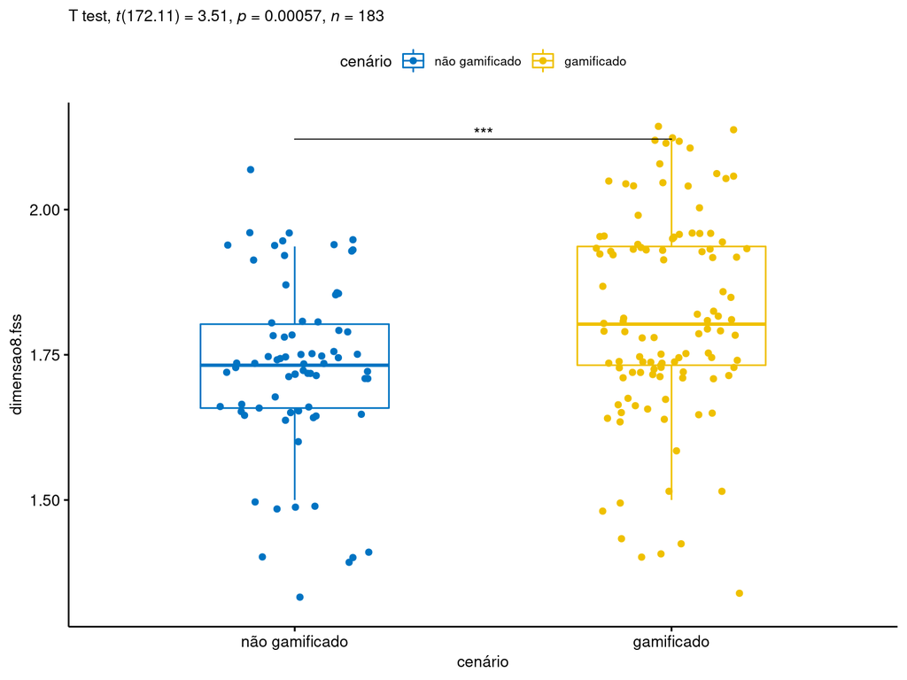

```r
ggPlotTTest(sdat[which(sdat[["var"]] == "dimensao8.fss"),], "cenário", "dimensao8.fss"
, res$tt[["dimensao8.fss"]], c("jitter"), font.label.size=10)
```

### T-Test plot for the dependent variable “dimensao7.fss”

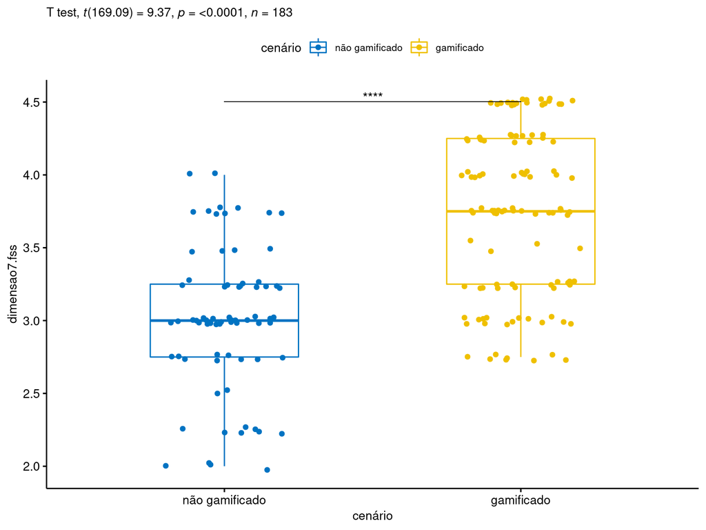

```r
ggPlotTTest(sdat[which(sdat[["var"]] == "dimensao7.fss"),], "cenário", "dimensao7.fss"
, res$tt[["dimensao7.fss"]], c("jitter"), font.label.size=10)
```

### T-Test plot for the dependent variable “dimensao5.fss”

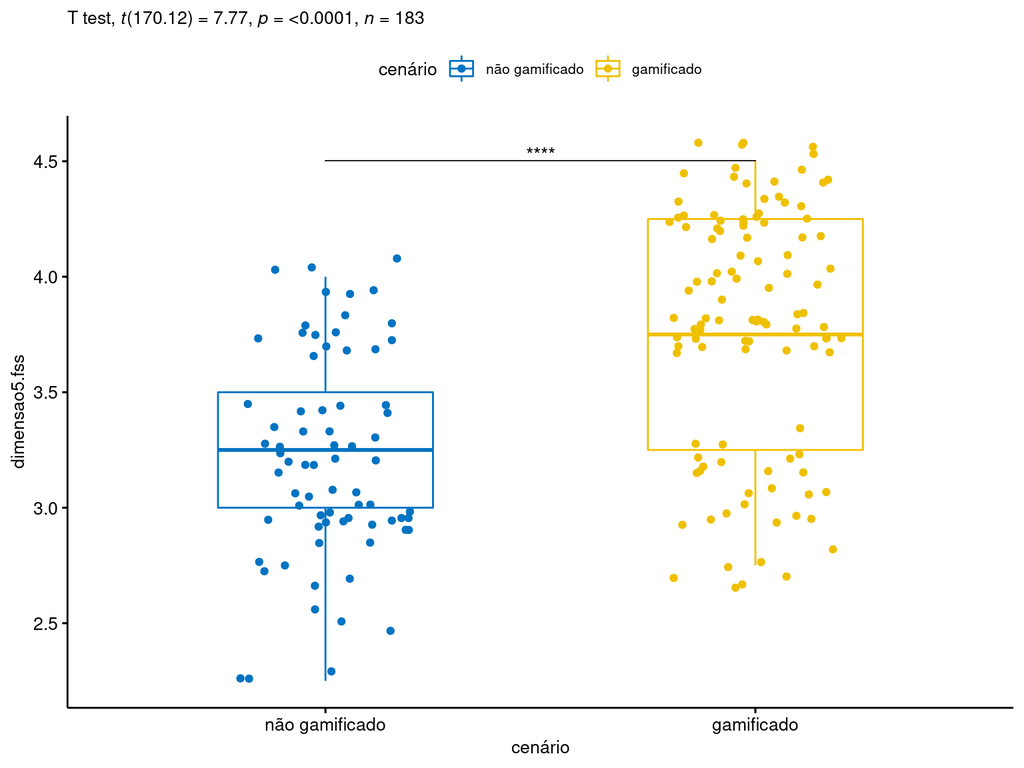

```r
ggPlotTTest(sdat[which(sdat[["var"]] == "dimensao5.fss"),], "cenário", "dimensao5.fss"
, res$tt[["dimensao5.fss"]], c("jitter"), font.label.size=10)
```